# Modeling thermal trade-offs versus trade-ups in a Resistance-vs-Recovery framework

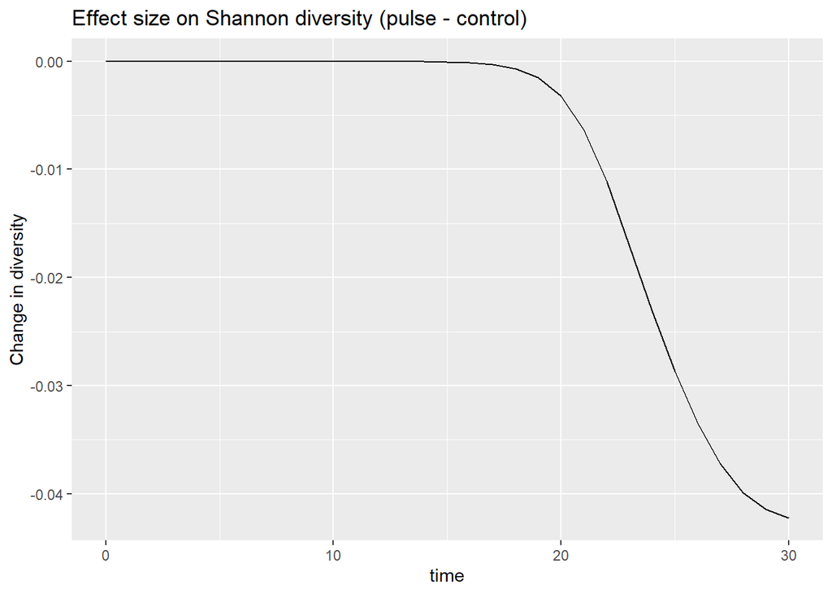

```r
# Shannon diversity
ggplot(effects_df %>%
         select(time, diversity),
       aes(x=time, y=diversity)) +
  geom_line() +
  labs(title = "Effect size on Shannon diversity (pulse - control)", y="Change in diversity")
```

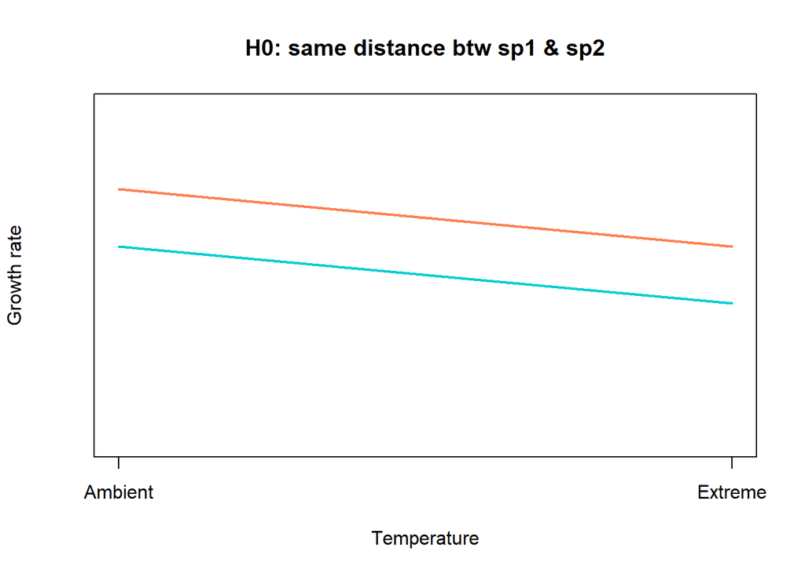

```r
# finally, we store the resistance vs recovery values for both productivity and diversity
RR_df <- data.frame(prod_resist = effects_df$productivity[which(effects_df$time == heat_pulse_times[2])],
                    prod_recov = effects_df$productivity[which(effects_df$time == heat_pulse_times[3])],
                    div_resist = effects_df$diversity[which(effects_df$time == heat_pulse_times[2])],
                    div_recov = effects_df$diversity[which(effects_df$time == heat_pulse_times[3])],
                    spF_ambient = sp1_ambient,
                    spF_extreme = sp1_extreme,
                    spS_ambient = sp2_ambient,
                    spS_extreme = sp2_extreme,
                    hypoth = "H0: same distance")


##################################### And again faster this time:
sp1_ambient <- 1.27
sp1_extreme <- 0.76

plot_muSchematic(fast_ambient = sp1_ambient, fast_extreme = sp1_extreme,
                 slo_ambient = sp2_ambient, slo_extreme = sp2_extreme,
                 plot_title = "H0: same distance btw sp1 & sp2")
```

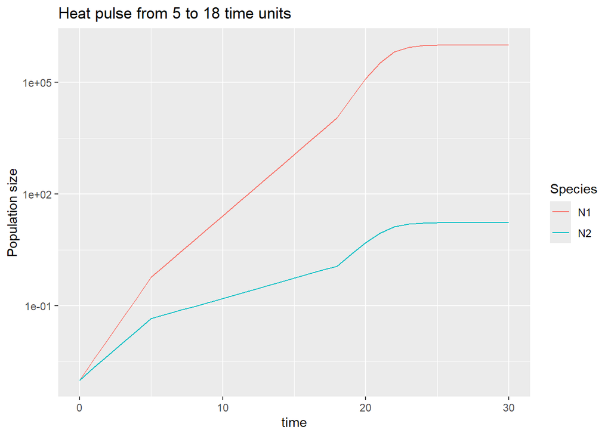

```r
# simulate the community with heat pulse
simEX <- sim_pulse(times=heat_pulse_times, init=State, K=carrying_cap,
                   mu_ambient=c(mu1=sp1_ambient, mu2=sp2_ambient), mu_extreme=c(mu1=sp1_extreme, mu2=sp2_extreme))

# plot the example under heat pulse conditions
ggplot(pivot_longer(simEX, cols = N1:N2),
       aes(x=time, y=value, colour=name)) +
  geom_line() +
  labs(title = "Heat pulse from 5 to 18 time units", y="Population size", colour = "Species") +
  scale_y_log10()
```

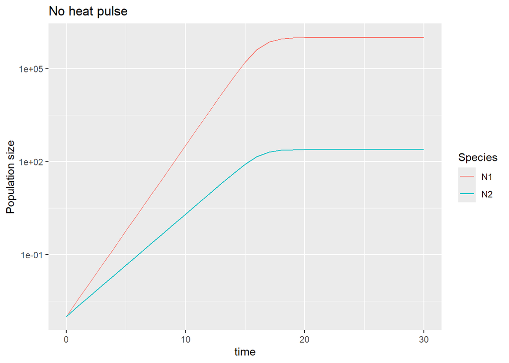

```r
# simulate the community WITHOUT heat pulse (i.e., no heat control)
simCTRL <- sim_1temp(time = 0:heat_pulse_times[3],
                   init = State,
                   params = c(K=carrying_cap, mu1=sp1_ambient, mu2=sp2_ambient))
# plot the no heat control:
ggplot(pivot_longer(simCTRL, cols = N1:N2),
       aes(x=time, y=value, colour=name)) +
  geom_line() +
  labs(title = "No heat pulse", y="Population size", colour = "Species") +
  scale_y_log10()
```

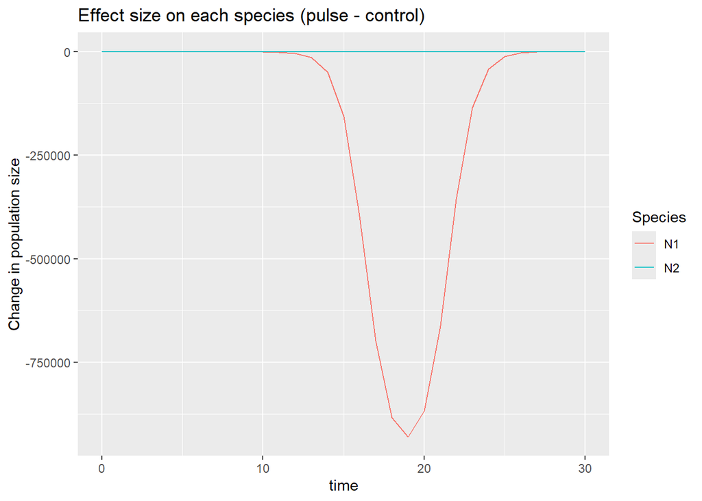

```r
################ let's look at the effect size in different ways:
effects_df <- heatVScontrol_effect(simdata_heat=simEX, simdata_control=simCTRL)

# plot per species
ggplot(effects_df %>%
         select(time, N1, N2) %>% pivot_longer(cols = N1:N2),
       aes(x=time, y=value, colour=name)) +
  geom_line() +
  labs(title = "Effect size on each species (pulse - control)", y="Change in population size", colour = "Species")
```

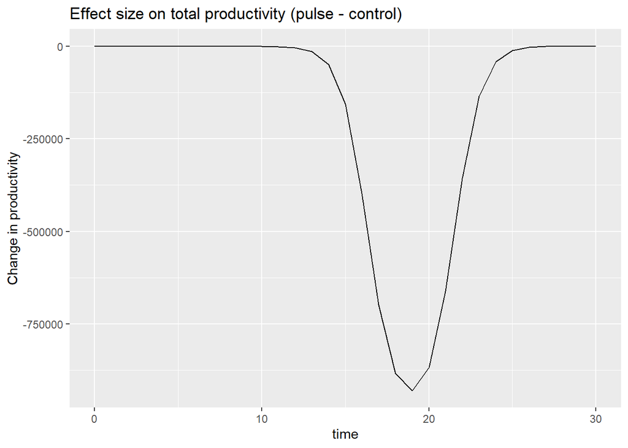

```r
# total productivity
ggplot(effects_df %>%
         select(time, productivity),
       aes(x=time, y=productivity)) +
  geom_line() +
  labs(title = "Effect size on total productivity (pulse - control)", y="Change in productivity")
```

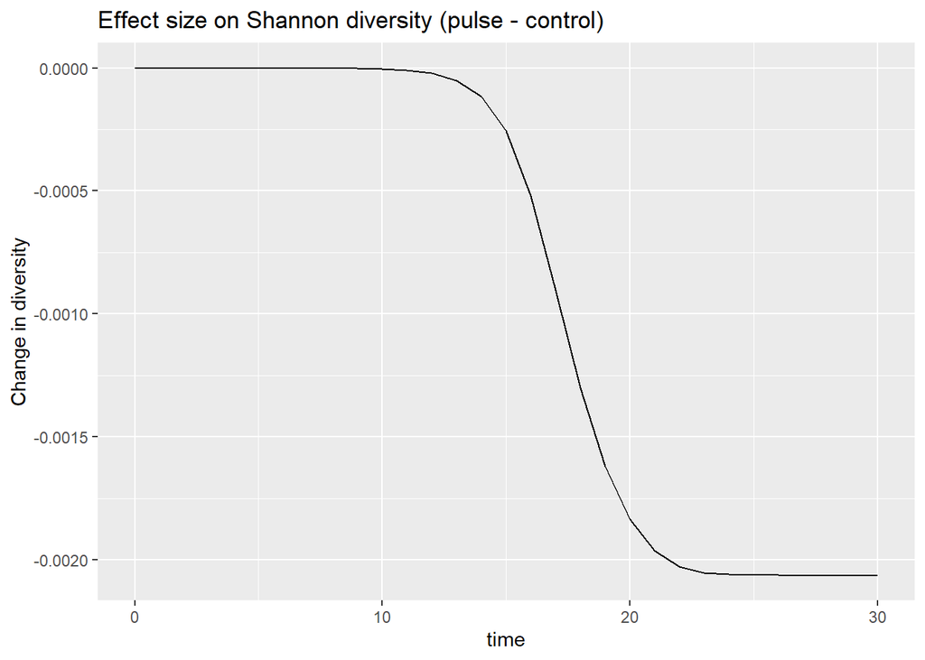

```r
# Shannon diversity
ggplot(effects_df %>%
         select(time, diversity),
       aes(x=time, y=diversity)) +
  geom_line() +
  labs(title = "Effect size on Shannon diversity (pulse - control)", y="Change in diversity")
```

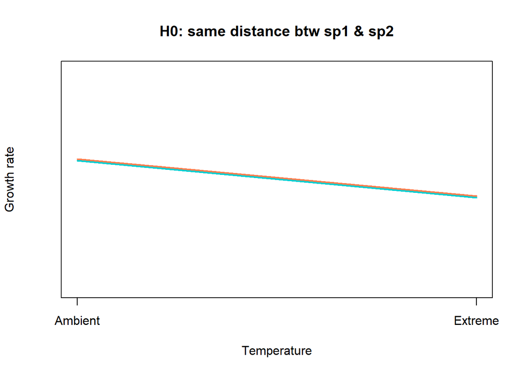

```r
# finally, we store the resistance vs recovery values for both productivity and diversity
temp <- data.frame(prod_resist = effects_df$productivity[which(effects_df$time == heat_pulse_times[2])],
                    prod_recov = effects_df$productivity[which(effects_df$time == heat_pulse_times[3])],
                    div_resist = effects_df$diversity[which(effects_df$time == heat_pulse_times[2])],
                    div_recov = effects_df$diversity[which(effects_df$time == heat_pulse_times[3])],
                    spF_ambient = sp1_ambient,
                    spF_extreme = sp1_extreme,
                    spS_ambient = sp2_ambient,
                    spS_extreme = sp2_extreme,
                    hypoth = "H0: same distance")
RR_df <- rbind(RR_df, temp)
rm(temp)

# clear memory
rm(simEX, simCTRL, effects_df)




##################################### aaaaand yet again slower this time:
sp1_ambient <- 0.78
sp1_extreme <- 0.27

plot_muSchematic(fast_ambient = sp1_ambient, fast_extreme = sp1_extreme,
                 slo_ambient = sp2_ambient, slo_extreme = sp2_extreme,
                 plot_title = "H0: same distance btw sp1 & sp2")
```

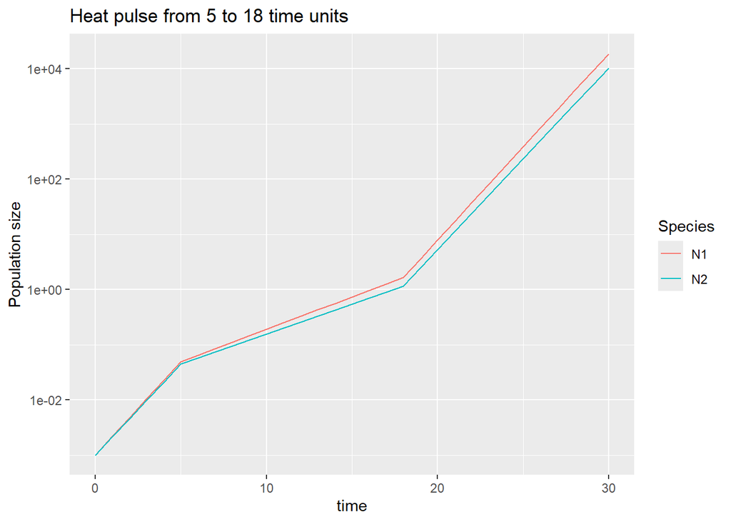

```r
# simulate the community with heat pulse
simEX <- sim_pulse(times=heat_pulse_times, init=State, K=carrying_cap,
                   mu_ambient=c(mu1=sp1_ambient, mu2=sp2_ambient), mu_extreme=c(mu1=sp1_extreme, mu2=sp2_extreme))

# plot the example under heat pulse conditions
ggplot(pivot_longer(simEX, cols = N1:N2),
       aes(x=time, y=value, colour=name)) +
  geom_line() +
  labs(title = "Heat pulse from 5 to 18 time units", y="Population size", colour = "Species") +
  scale_y_log10()
```

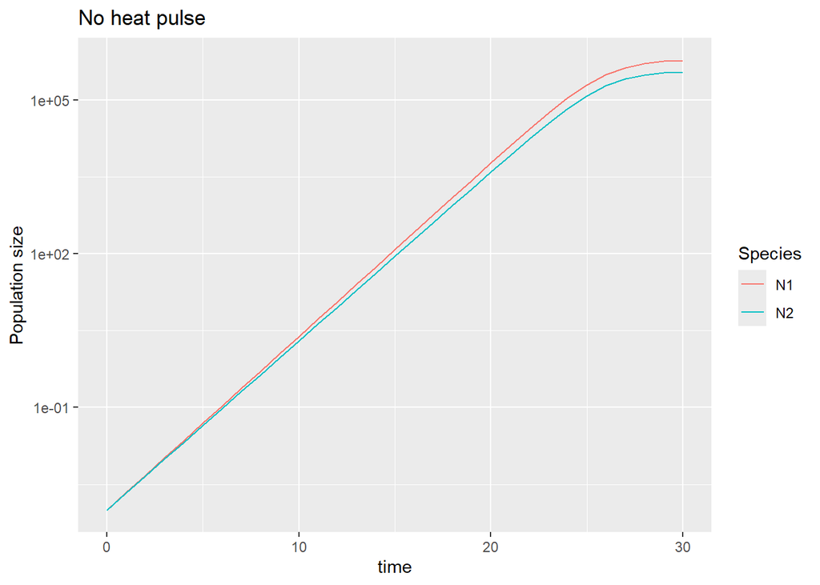

```r
# simulate the community WITHOUT heat pulse (i.e., no heat control)
simCTRL <- sim_1temp(time = 0:heat_pulse_times[3],
                   init = State,
                   params = c(K=carrying_cap, mu1=sp1_ambient, mu2=sp2_ambient))
# plot the no heat control:
ggplot(pivot_longer(simCTRL, cols = N1:N2),
       aes(x=time, y=value, colour=name)) +
  geom_line() +
  labs(title = "No heat pulse", y="Population size", colour = "Species") +
  scale_y_log10()
```

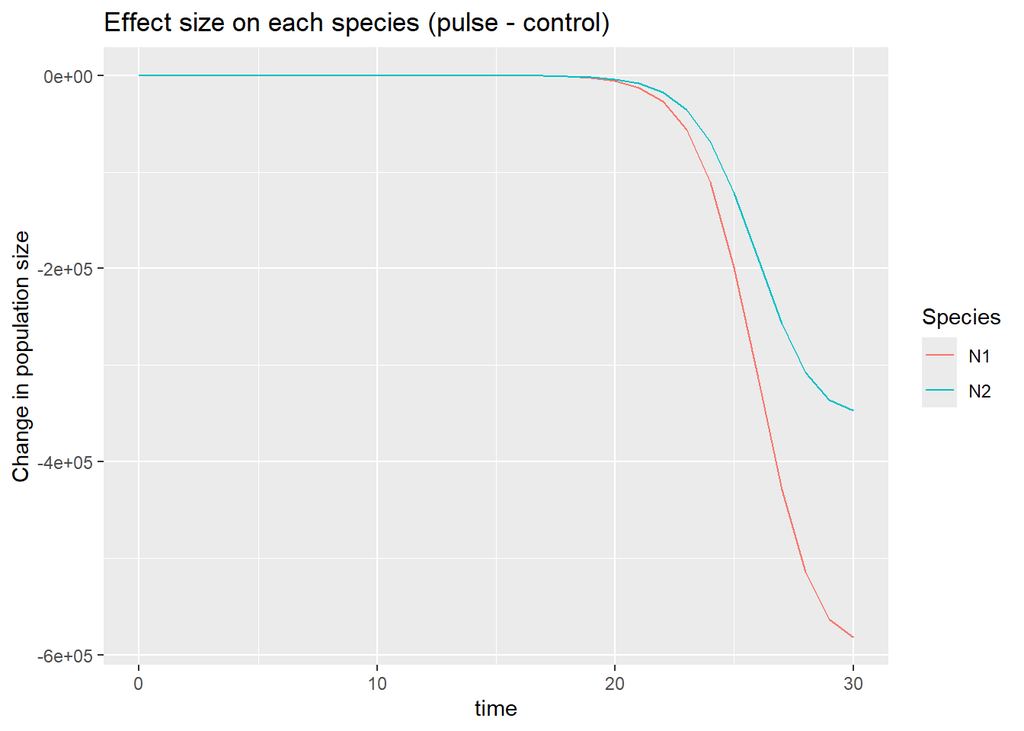

```r
################ let's look at the effect size in different ways:
effects_df <- heatVScontrol_effect(simdata_heat=simEX, simdata_control=simCTRL)

# plot per species
ggplot(effects_df %>%
         select(time, N1, N2) %>% pivot_longer(cols = N1:N2),
       aes(x=time, y=value, colour=name)) +
  geom_line() +
  labs(title = "Effect size on each species (pulse - control)", y="Change in population size", colour = "Species")
```

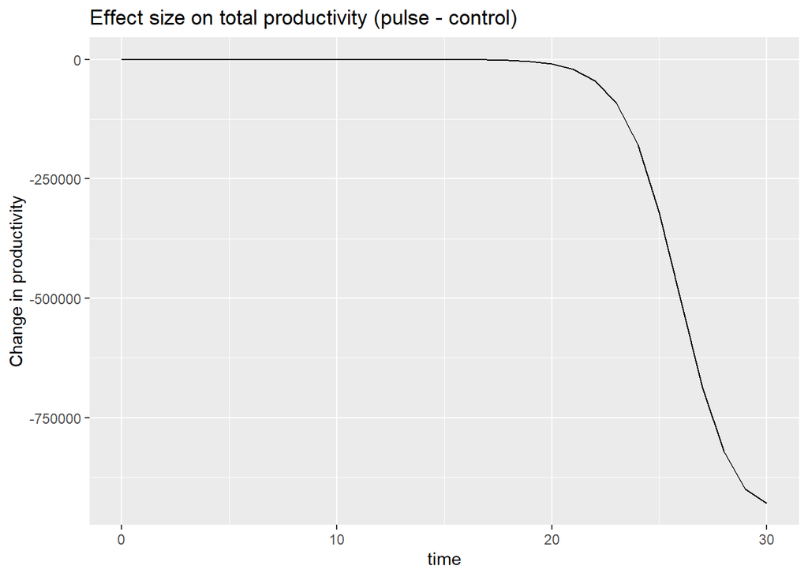

```r
# total productivity
ggplot(effects_df %>%
         select(time, productivity),
       aes(x=time, y=productivity)) +
  geom_line() +
  labs(title = "Effect size on total productivity (pulse - control)", y="Change in productivity")
```

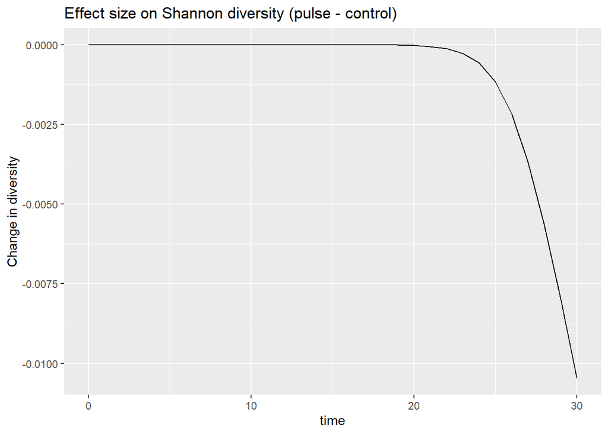

```r
# Shannon diversity
ggplot(effects_df %>%
         select(time, diversity),
       aes(x=time, y=diversity)) +
  geom_line() +
  labs(title = "Effect size on Shannon diversity (pulse - control)", y="Change in diversity")
```

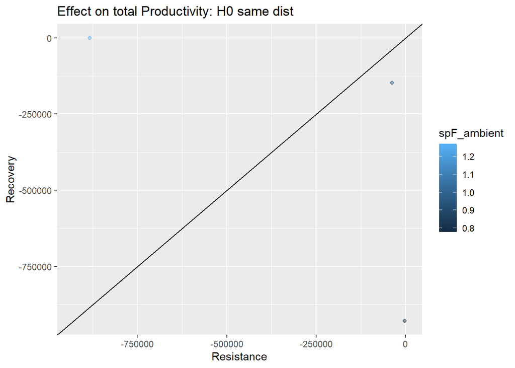

```r
# finally, we store the resistance vs recovery values for both productivity and diversity
temp <- data.frame(prod_resist = effects_df$productivity[which(effects_df$time == heat_pulse_times[2])],
                    prod_recov = effects_df$productivity[which(effects_df$time == heat_pulse_times[3])],
                    div_resist = effects_df$diversity[which(effects_df$time == heat_pulse_times[2])],
                    div_recov = effects_df$diversity[which(effects_df$time == heat_pulse_times[3])],
                    spF_ambient = sp1_ambient,
                    spF_extreme = sp1_extreme,
                    spS_ambient = sp2_ambient,
                    spS_extreme = sp2_extreme,
                    hypoth = "H0: same distance")
RR_df <- rbind(RR_df, temp)
rm(temp)
# clear memory
rm(simEX, simCTRL, effects_df)

##################### Finally we plot resistance vs recovery
ggplot(RR_df %>% filter(hypoth == "H0: same distance"),
       aes(x = prod_resist, y = prod_recov, colour = spF_ambient)) +
  geom_point(alpha=0.5) +
  geom_abline(intercept = 0, slope = 1, color = "black") +
  xlim(range(unlist(RR_df[,1:2]))) +
  ylim(range(unlist(RR_df[,1:2]))) +
  labs(title = "Effect on total Productivity: H0 same dist", x="Resistance", y="Recovery")
```

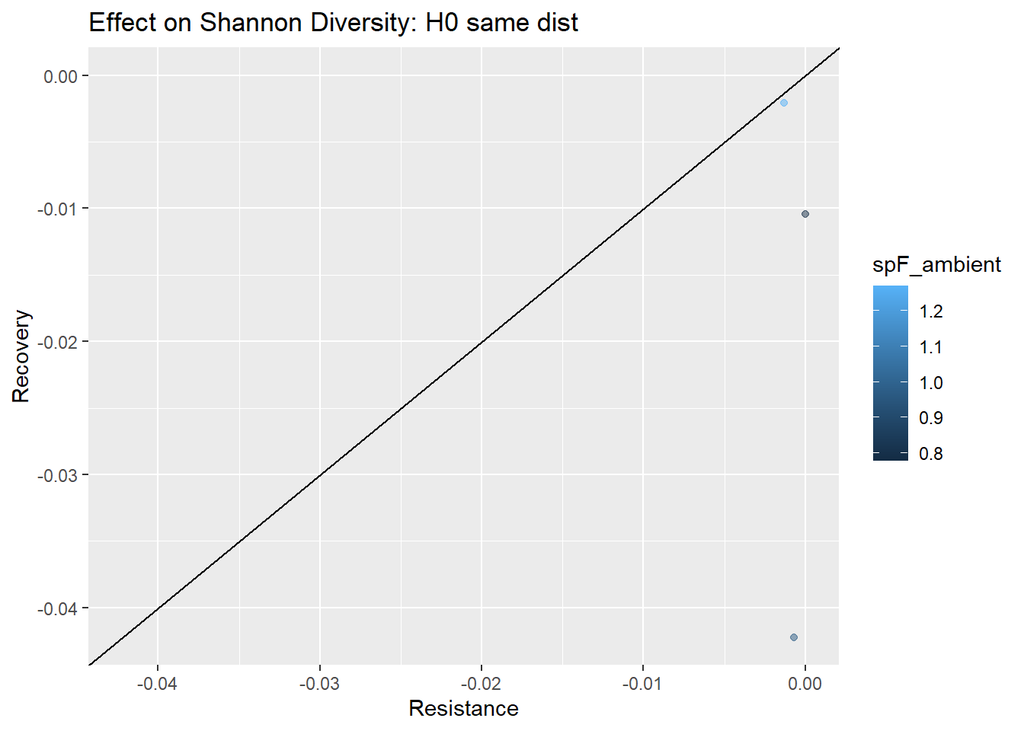

```r
ggplot(RR_df %>% filter(hypoth == "H0: same distance"),
       aes(x = div_resist, y = div_recov, colour = spF_ambient)) +
  geom_point(alpha=0.5) +
  geom_abline(intercept = 0, slope = 1, color = "black") +
  xlim(range(unlist(RR_df[,3:4]))) +
  ylim(range(unlist(RR_df[,3:4]))) +
  labs(title = "Effect on Shannon Diversity: H0 same dist", x="Resistance", y="Recovery")
```

### Summary

In general, our prediction of having coupling between resistance & recovery under the null hypothesis is **not** borne out.

For **Total Productivity**, there is *usually decoupling that falls below* the $y=x$ line. What this means is that the heat pulse prevents everyone from growing as much as they would otherwise in the absence of a pulse, both at the peak of the heat pulse (when we measure resistance) and even some time after the heat pulse has ended (when we measure recovery) the community’s total productivity hasn’t yet had time to catch up.

The productivity “decoupling” below the $y=x$ line does not seem to matter much on the difference in growth rates between the fast and slow species. Instead it depends on the growth rate of the fast species (or, equivalently, on the duration of the heat pulse): if this is fast enough to get to carrying capacity then the **decoupling can be above** the $y=x$ line.

The explanation above applies primarily to the “same distance” H0, something slightly different is happening for the “same ratio” H0. Here the advantage of the fast grower is actually *decreased* during the heat pulse. That’s what allows diversity to go up during the heat pulse… except that for some reason it usually goes back down by the end of the heat pulse (when we measure recovery). Anyway, I expect to see more of this diversity-increasing effect of the heat pulse when we look at the trade-off hypothesis.

## Trade-ups

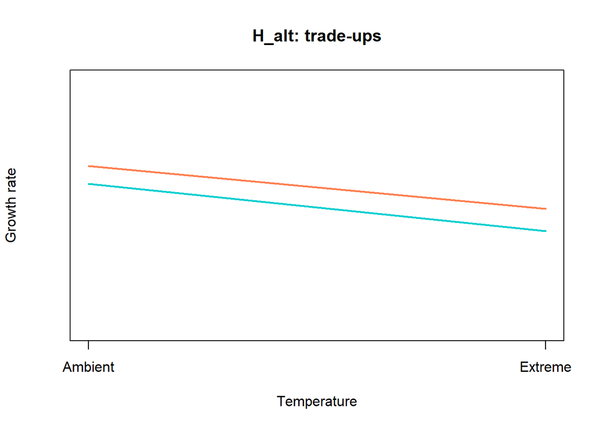

```r
# keep all of these parameter values fixed:
State <- c(N1=0.001, N2=0.001)
heat_pulse_times <- c(5,18,30)
carrying_cap <- 10^6
sp1_ambient <- 0.97
sp1_extreme <- 0.46
sp2_ambient <- 0.76

# just modify this parameter value:
sp2_extreme <- 0.19

plot_muSchematic(fast_ambient = sp1_ambient, fast_extreme = sp1_extreme,
                 slo_ambient = sp2_ambient, slo_extreme = sp2_extreme,
                 plot_title = "H_alt: trade-ups")
```

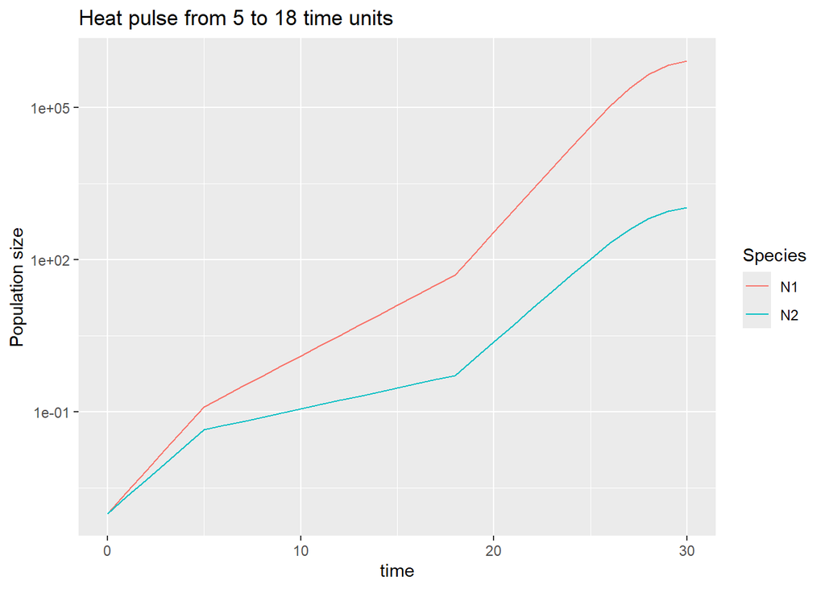

```r
# simulate the community with heat pulse
simEX <- sim_pulse(times=heat_pulse_times, init=State, K=carrying_cap,
                   mu_ambient=c(mu1=sp1_ambient, mu2=sp2_ambient), mu_extreme=c(mu1=sp1_extreme, mu2=sp2_extreme))

# plot the example under heat pulse conditions
ggplot(pivot_longer(simEX, cols = N1:N2),
       aes(x=time, y=value, colour=name)) +
  geom_line() +
  labs(title = "Heat pulse from 5 to 18 time units", y="Population size", colour = "Species") +
  scale_y_log10()
```

```r
# simulate the community WITHOUT heat pulse (i.e., no heat control)
simCTRL <- sim_1temp(time = 0:heat_pulse_times[3],
                   init = State,
                   params = c(K=carrying_cap, mu1=sp1_ambient, mu2=sp2_ambient))
# plot the no heat control:
ggplot(pivot_longer(simCTRL, cols = N1:N2),
       aes(x=time, y=value, colour=name)) +
  geom_line() +
  labs(title = "No heat pulse", y="Population size", colour = "Species") +
  scale_y_log10()
```

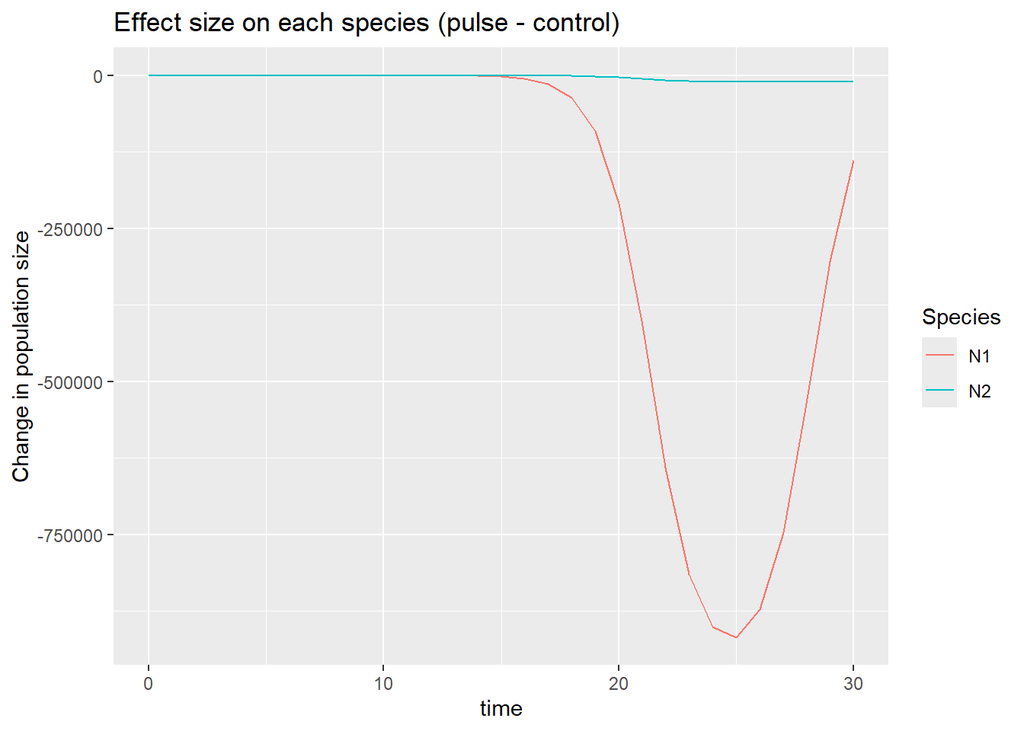

```r
################ let's look at the effect size in different ways:
effects_df <- heatVScontrol_effect(simdata_heat=simEX, simdata_control=simCTRL)

# plot per species
ggplot(effects_df %>%
         select(time, N1, N2) %>% pivot_longer(cols = N1:N2),
       aes(x=time, y=value, colour=name)) +
  geom_line() +
  labs(title = "Effect size on each species (pulse - control)", y="Change in population size", colour = "Species")
```

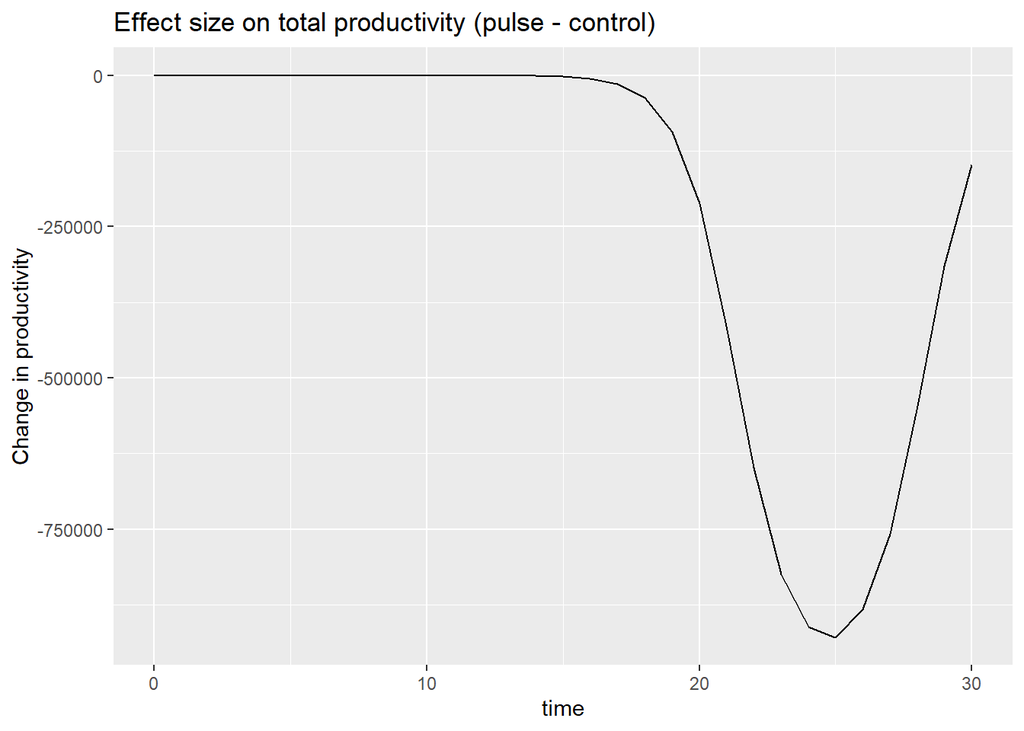

```r
# total productivity
ggplot(effects_df %>%
         select(time, productivity),
       aes(x=time, y=productivity)) +
  geom_line() +
  labs(title = "Effect size on total productivity (pulse - control)", y="Change in productivity")
```

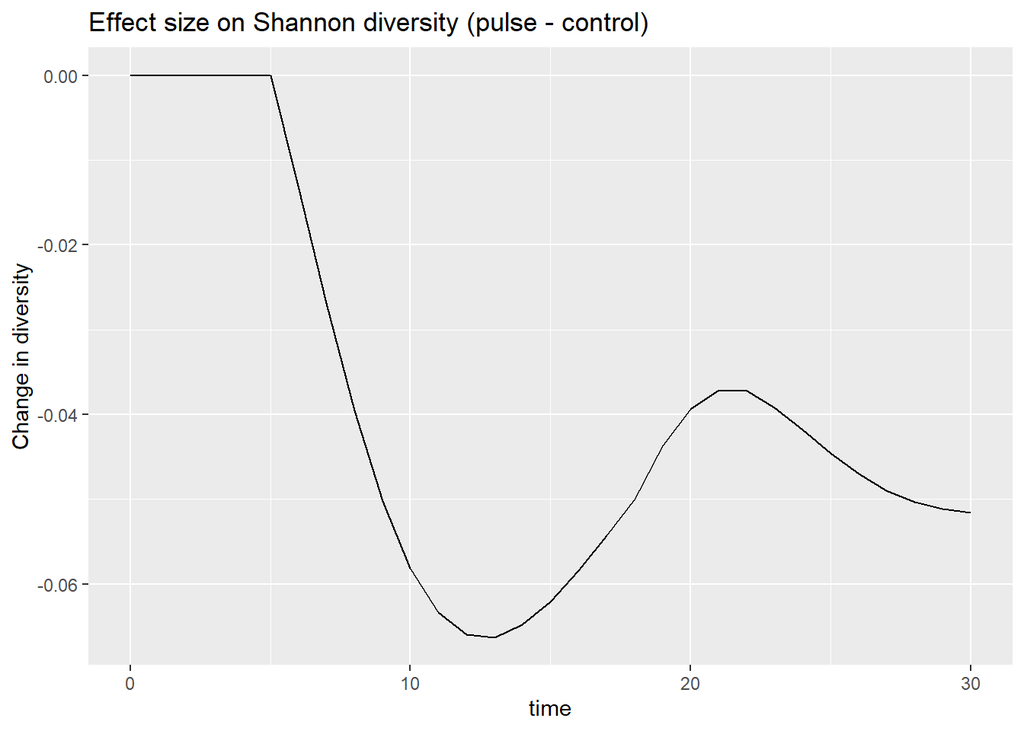

```r
# Shannon diversity
ggplot(effects_df %>%
         select(time, diversity),
       aes(x=time, y=diversity)) +
  geom_line() +
  labs(title = "Effect size on Shannon diversity (pulse - control)", y="Change in diversity")
```

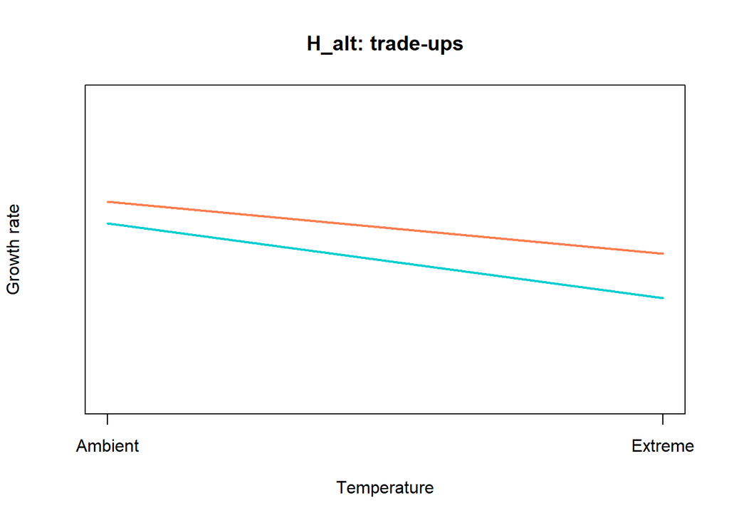

```r
# finally, we store the resistance vs recovery values for both productivity and diversity
temp <- data.frame(prod_resist = effects_df$productivity[which(effects_df$time == heat_pulse_times[2])],
                    prod_recov = effects_df$productivity[which(effects_df$time == heat_pulse_times[3])],
                    div_resist = effects_df$diversity[which(effects_df$time == heat_pulse_times[2])],
                    div_recov = effects_df$diversity[which(effects_df$time == heat_pulse_times[3])],
                    spF_ambient = sp1_ambient,
                    spF_extreme = sp1_extreme,
                    spS_ambient = sp2_ambient,
                    spS_extreme = sp2_extreme,
                    hypoth = "H_alt: trade-ups")
# keep the 1st row of the H0 results for comparison
RR_df <- rbind(RR_df[1,], temp)
rm(temp)
# clear memory
rm(simEX, simCTRL, effects_df)


##################################### Try again with larger trade-up (but still positive growth for slow grower):
sp2_extreme <- 0.019

plot_muSchematic(fast_ambient = sp1_ambient, fast_extreme = sp1_extreme,
                 slo_ambient = sp2_ambient, slo_extreme = sp2_extreme,
                 plot_title = "H_alt: trade-ups")
```

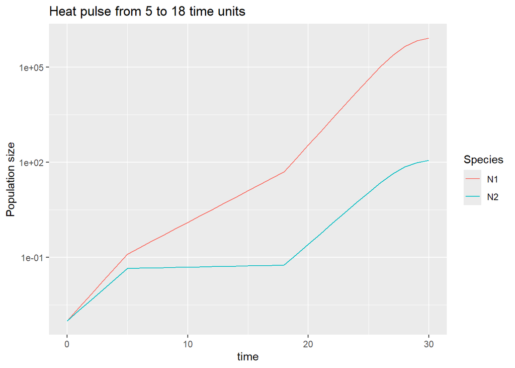

```r
# simulate the community with heat pulse
simEX <- sim_pulse(times=heat_pulse_times, init=State, K=carrying_cap,
                   mu_ambient=c(mu1=sp1_ambient, mu2=sp2_ambient), mu_extreme=c(mu1=sp1_extreme, mu2=sp2_extreme))

# plot the example under heat pulse conditions
ggplot(pivot_longer(simEX, cols = N1:N2),
       aes(x=time, y=value, colour=name)) +
  geom_line() +
  labs(title = "Heat pulse from 5 to 18 time units", y="Population size", colour = "Species") +
  scale_y_log10()
```

```r
# simulate the community WITHOUT heat pulse (i.e., no heat control)
simCTRL <- sim_1temp(time = 0:heat_pulse_times[3],
                   init = State,
                   params = c(K=carrying_cap, mu1=sp1_ambient, mu2=sp2_ambient))
# plot the no heat control:
ggplot(pivot_longer(simCTRL, cols = N1:N2),
       aes(x=time, y=value, colour=name)) +
  geom_line() +
  labs(title = "No heat pulse", y="Population size", colour = "Species") +
  scale_y_log10()
```

```r
################ let's look at the effect size in different ways:
effects_df <- heatVScontrol_effect(simdata_heat=simEX, simdata_control=simCTRL)

# plot per species
ggplot(effects_df %>%
         select(time, N1, N2) %>% pivot_longer(cols = N1:N2),
       aes(x=time, y=value, colour=name)) +
  geom_line() +
  labs(title = "Effect size on each species (pulse - control)", y="Change in population size", colour = "Species")
```

```r
# total productivity
ggplot(effects_df %>%
         select(time, productivity),
       aes(x=time, y=productivity)) +
  geom_line() +
  labs(title = "Effect size on total productivity (pulse - control)", y="Change in productivity")
```

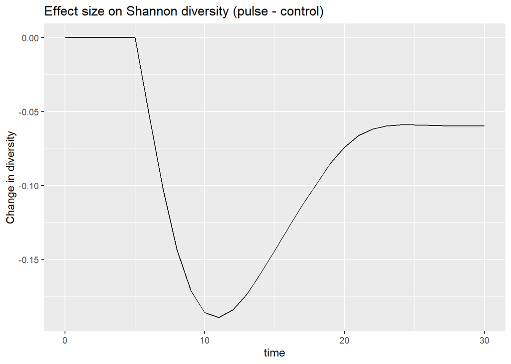

```r
# Shannon diversity
ggplot(effects_df %>%
         select(time, diversity),
       aes(x=time, y=diversity)) +
  geom_line() +
  labs(title = "Effect size on Shannon diversity (pulse - control)", y="Change in diversity")
```

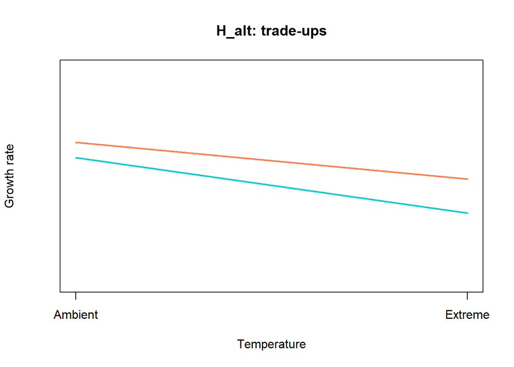

```r
# finally, we store the resistance vs recovery values for both productivity and diversity
temp <- data.frame(prod_resist = effects_df$productivity[which(effects_df$time == heat_pulse_times[2])],
                    prod_recov = effects_df$productivity[which(effects_df$time == heat_pulse_times[3])],
                    div_resist = effects_df$diversity[which(effects_df$time == heat_pulse_times[2])],
                    div_recov = effects_df$diversity[which(effects_df$time == heat_pulse_times[3])],
                    spF_ambient = sp1_ambient,
                    spF_extreme = sp1_extreme,
                    spS_ambient = sp2_ambient,
                    spS_extreme = sp2_extreme,
                    hypoth = "H_alt: trade-ups")
RR_df <- rbind(RR_df, temp)
rm(temp)
# clear memory
rm(simEX, simCTRL, effects_df)


##################################### slightly larger trade-up but now with negative growth for the slow grower
sp2_extreme <- -0.019

plot_muSchematic(fast_ambient = sp1_ambient, fast_extreme = sp1_extreme,
                 slo_ambient = sp2_ambient, slo_extreme = sp2_extreme,
                 plot_title = "H_alt: trade-ups")
```

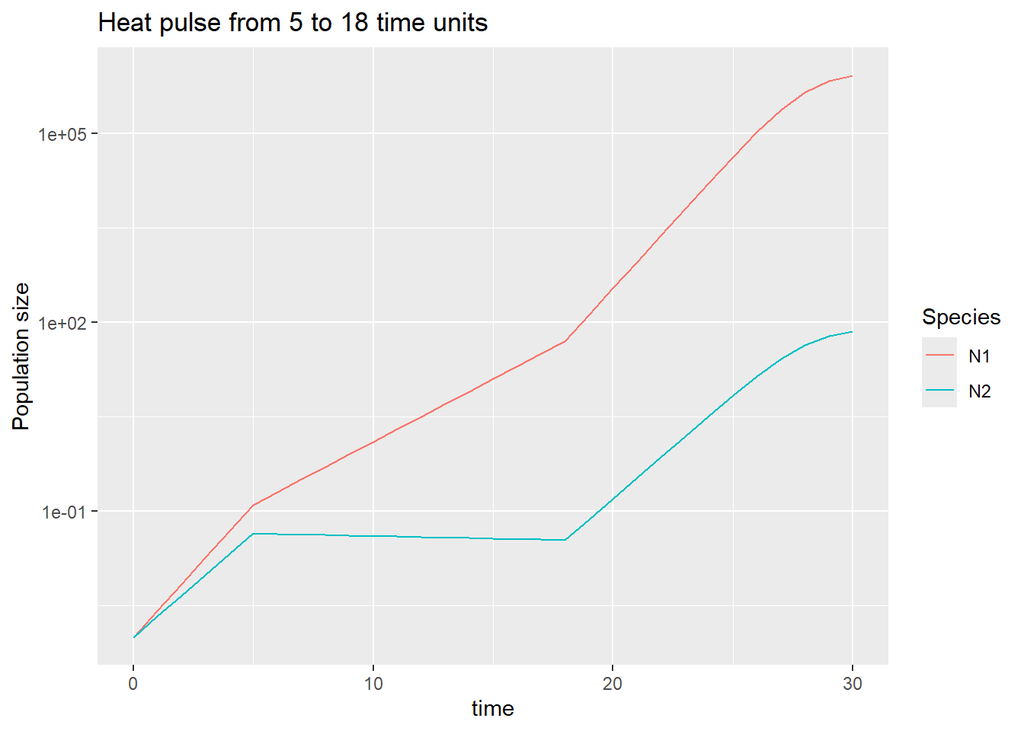

```r
# simulate the community with heat pulse
simEX <- sim_pulse(times=heat_pulse_times, init=State, K=carrying_cap,
                   mu_ambient=c(mu1=sp1_ambient, mu2=sp2_ambient), mu_extreme=c(mu1=sp1_extreme, mu2=sp2_extreme))

# plot the example under heat pulse conditions
ggplot(pivot_longer(simEX, cols = N1:N2),
       aes(x=time, y=value, colour=name)) +
  geom_line() +
  labs(title = "Heat pulse from 5 to 18 time units", y="Population size", colour = "Species") +
  scale_y_log10()
```

```r
# simulate the community WITHOUT heat pulse (i.e., no heat control)
simCTRL <- sim_1temp(time = 0:heat_pulse_times[3],
                   init = State,
                   params = c(K=carrying_cap, mu1=sp1_ambient, mu2=sp2_ambient))
# plot the no heat control:
ggplot(pivot_longer(simCTRL, cols = N1:N2),
       aes(x=time, y=value, colour=name)) +
  geom_line() +
  labs(title = "No heat pulse", y="Population size", colour = "Species") +
  scale_y_log10()
```

```r
################ let's look at the effect size in different ways:
effects_df <- heatVScontrol_effect(simdata_heat=simEX, simdata_control=simCTRL)

# plot per species
ggplot(effects_df %>%
         select(time, N1, N2) %>% pivot_longer(cols = N1:N2),
       aes(x=time, y=value, colour=name)) +
  geom_line() +
  labs(title = "Effect size on each species (pulse - control)", y="Change in population size", colour = "Species")
```

```r
# total productivity
ggplot(effects_df %>%
         select(time, productivity),
       aes(x=time, y=productivity)) +
  geom_line() +
  labs(title = "Effect size on total productivity (pulse - control)", y="Change in productivity")
```

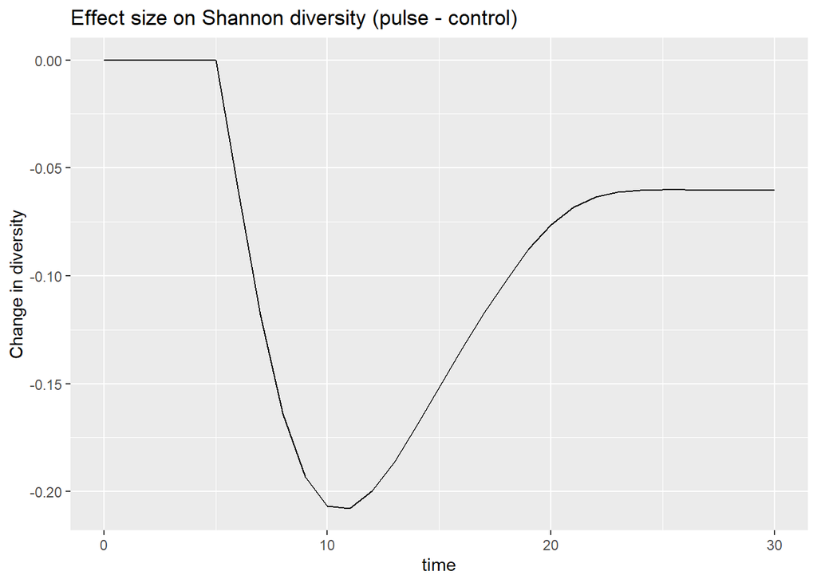

```r
# Shannon diversity
ggplot(effects_df %>%
         select(time, diversity),
       aes(x=time, y=diversity)) +
  geom_line() +
  labs(title = "Effect size on Shannon diversity (pulse - control)", y="Change in diversity")
```

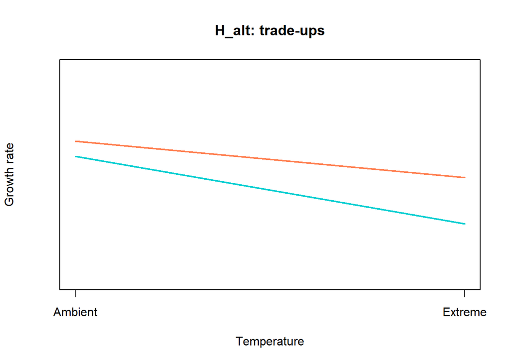

```r
# finally, we store the resistance vs recovery values for both productivity and diversity
temp <- data.frame(prod_resist = effects_df$productivity[which(effects_df$time == heat_pulse_times[2])],
                    prod_recov = effects_df$productivity[which(effects_df$time == heat_pulse_times[3])],
                    div_resist = effects_df$diversity[which(effects_df$time == heat_pulse_times[2])],
                    div_recov = effects_df$diversity[which(effects_df$time == heat_pulse_times[3])],
                    spF_ambient = sp1_ambient,
                    spF_extreme = sp1_extreme,
                    spS_ambient = sp2_ambient,
                    spS_extreme = sp2_extreme,
                    hypoth = "H_alt: trade-ups")
RR_df <- rbind(RR_df, temp)
rm(temp)
# clear memory
rm(simEX, simCTRL, effects_df)

##################################### the last one is near where we might expect the slow grower to go extinct (if that was possible in our model)
sp2_extreme <- -0.19

plot_muSchematic(fast_ambient = sp1_ambient, fast_extreme = sp1_extreme,
                 slo_ambient = sp2_ambient, slo_extreme = sp2_extreme,
                 plot_title = "H_alt: trade-ups")
```

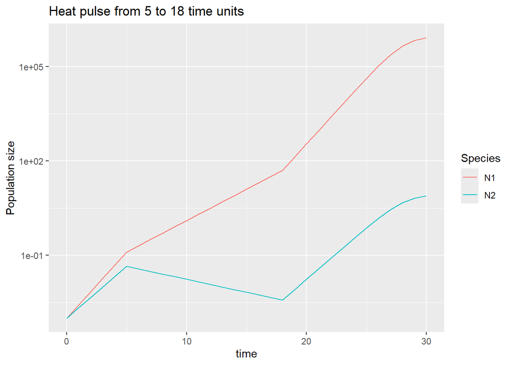

```r
# simulate the community with heat pulse
simEX <- sim_pulse(times=heat_pulse_times, init=State, K=carrying_cap,
                   mu_ambient=c(mu1=sp1_ambient, mu2=sp2_ambient), mu_extreme=c(mu1=sp1_extreme, mu2=sp2_extreme))

# plot the example under heat pulse conditions
ggplot(pivot_longer(simEX, cols = N1:N2),
       aes(x=time, y=value, colour=name)) +
  geom_line() +
  labs(title = "Heat pulse from 5 to 18 time units", y="Population size", colour = "Species") +
  scale_y_log10()
```

```r
# simulate the community WITHOUT heat pulse (i.e., no heat control)
simCTRL <- sim_1temp(time = 0:heat_pulse_times[3],
                   init = State,
                   params = c(K=carrying_cap, mu1=sp1_ambient, mu2=sp2_ambient))
# plot the no heat control:
ggplot(pivot_longer(simCTRL, cols = N1:N2),
       aes(x=time, y=value, colour=name)) +
  geom_line() +
  labs(title = "No heat pulse", y="Population size", colour = "Species") +
  scale_y_log10()
```

```r
################ let's look at the effect size in different ways:
effects_df <- heatVScontrol_effect(simdata_heat=simEX, simdata_control=simCTRL)

# plot per species
ggplot(effects_df %>%
         select(time, N1, N2) %>% pivot_longer(cols = N1:N2),
       aes(x=time, y=value, colour=name)) +
  geom_line() +
  labs(title = "Effect size on each species (pulse - control)", y="Change in population size", colour = "Species")
```

```r
# total productivity
ggplot(effects_df %>%
         select(time, productivity),
       aes(x=time, y=productivity)) +
  geom_line() +
  labs(title = "Effect size on total productivity (pulse - control)", y="Change in productivity")
```

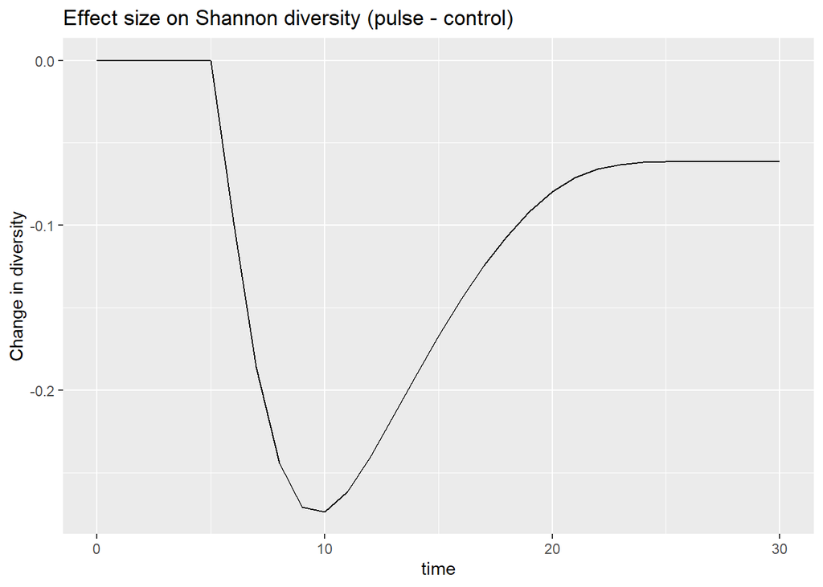

```r
# Shannon diversity
ggplot(effects_df %>%
         select(time, diversity),
       aes(x=time, y=diversity)) +
  geom_line() +
  labs(title = "Effect size on Shannon diversity (pulse - control)", y="Change in diversity")
```

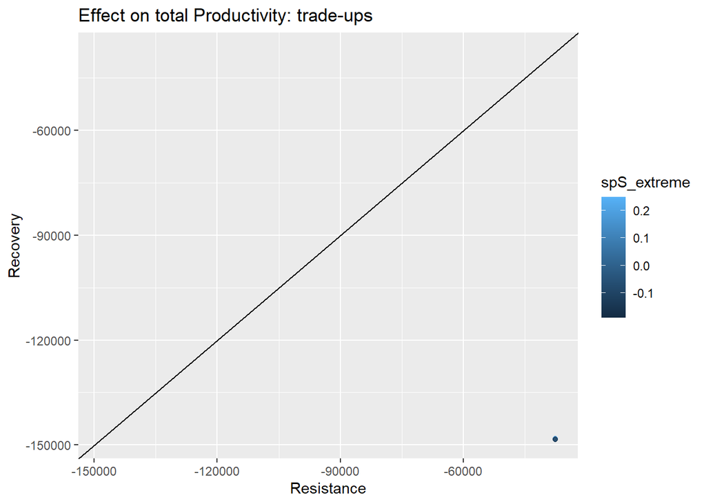

```r
# finally, we store the resistance vs recovery values for both productivity and diversity
temp <- data.frame(prod_resist = effects_df$productivity[which(effects_df$time == heat_pulse_times[2])],
                    prod_recov = effects_df$productivity[which(effects_df$time == heat_pulse_times[3])],
                    div_resist = effects_df$diversity[which(effects_df$time == heat_pulse_times[2])],
                    div_recov = effects_df$diversity[which(effects_df$time == heat_pulse_times[3])],
                    spF_ambient = sp1_ambient,
                    spF_extreme = sp1_extreme,
                    spS_ambient = sp2_ambient,
                    spS_extreme = sp2_extreme,
                    hypoth = "H_alt: trade-ups")
RR_df <- rbind(RR_df, temp)
rm(temp)
# clear memory
rm(simEX, simCTRL, effects_df)

##################### Finally we plot resistance vs recovery
ggplot(RR_df,
       aes(x = prod_resist, y = prod_recov, colour = spS_extreme)) +
  geom_point(alpha=0.5) +
  geom_abline(intercept = 0, slope = 1, color = "black") +
  xlim(range(unlist(RR_df[,1:2]))) +
  ylim(range(unlist(RR_df[,1:2]))) +
  labs(title = "Effect on total Productivity: trade-ups", x="Resistance", y="Recovery")
```

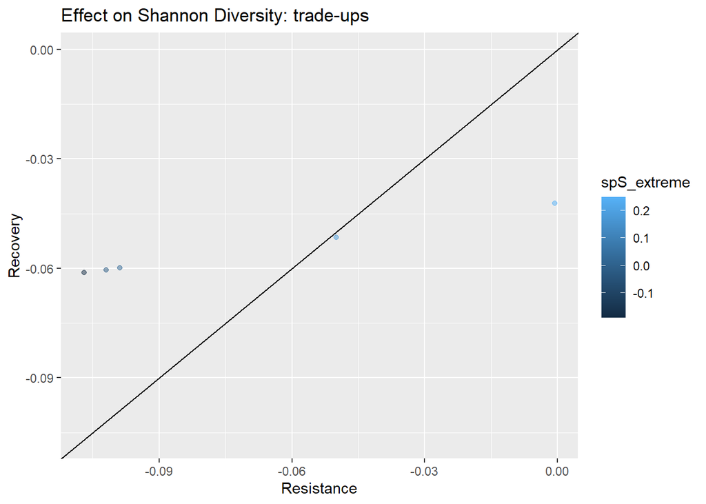

```r
ggplot(RR_df,
       aes(x = div_resist, y = div_recov, colour = spS_extreme)) +
  geom_point(alpha=0.5) +
  geom_abline(intercept = 0, slope = 1, color = "black") +
  xlim(range(unlist(RR_df[,3:4]))) +
  ylim(range(unlist(RR_df[,3:4]))) +
  labs(title = "Effect on Shannon Diversity: trade-ups", x="Resistance", y="Recovery")
```

```r
# keep these results for the final summary plot
final_RR_df <- rbind(final_RR_df,
                     RR_df %>% filter(hypoth == "H_alt: trade-ups"))
```

**Summary:** There’s no impact of trade-ups on total productivity. This makes sense with what we already learned from the null model: the extent of “decoupling” for total productivity depends on the growth rate of the fastest growing species.

For diversity, a larger trade-up pushes the resistance effect to larger negative values (i.e., towards the left), which makes sense because the heat pulse accentuates the advantage of the fast grower. If the trade-up is large enough, then it’s possible for the “decoupling” to be above the $y=x$ line because it’s during the recovery phase that the slow grower is able to catch up on the fast grower, therefore leading to relatively more diversity during recovery than during resistance. Note that this is somehow in line with the trivial “coupling” at (0,0) observed when there’s a big difference between the fast and slow grower under the null hypothesis.